# Análisis de muestras y tasas de letalidad en Provincias

Análisis de las provincias con más fallecidos(confirmados y probables de covid19) que se ha reportado en la página del MSP hasta el día 2020-05-03.

##### Fallecidos

mc = muerte confirmada, mp = muerte probable de covid19, pmc= porcentaje de muertes confirmadas, pmp= porcentaje de muertes probables, pmt= porcentaje de muertes totales

| prov | mc | mp | Representatividad Nacional pmc | Representatividad Nacional pmp | Representatividad Nacional pmt | total |
| --- | --- | --- | --- | --- | --- | --- |
| Guayas | 683 | 792 | 43.7 % | 60.4 % | 51.3 % | 1475 |
| Manabi | 206 | 211 | 13.2 % | 16.1 % | 14.5 % | 417 |
| Santa Elena | 164 | 172 | 10.5 % | 13.1 % | 11.7 % | 336 |
| Los Rios | 59 | 75 | 3.8 % | 5.7 % | 4.7 % | 134 |
| El Oro | 106 | 25 | 6.8 % | 1.9 % | 4.6 % | 131 |
| Pichincha | 91 | 3 | 5.8 % | 0.2 % | 3.3 % | 94 |
| Chimborazo | 52 | 10 | 3.3 % | 0.8 % | 2.2 % | 62 |
| Santo Domingo | 35 | 8 | 2.2 % | 0.6 % | 1.5 % | 43 |
| Tungurahua | 32 | 4 | 2 % | 0.3 % | 1.3 % | 36 |
| Esmeraldas | 28 | 2 | 1.8 % | 0.2 % | 1 % | 30 |
| Cotopaxi | 25 | 3 | 1.6 % | 0.2 % | 1 % | 28 |

### Porcentaje de pruebas por provincia

Análisis de la participación (porcentajes) de las pruebas tomadas, confirmadas, descartadas y en espera de cada provincia con respecto al nacional.

p_tomadas = porcentaje pruebas tomadas, p_confirmados= porcentaje de pruebas confirmados, p_espera= porcentaje pruebas espera, p_descartado= porcentaje pruebas descartadas

| prov | m_tomadas | confirmadas | espera | descartado | p_tomadas | p_confirmados | p_espera | p_descaratdo |
| --- | --- | --- | --- | --- | --- | --- | --- | --- |
| Guayas | 31077 | 13053 | 7509 | 9723 | 50.7 % | 62.3 % | 46.3 % | 42.7 % |
| Pichincha | 6950 | 1698 | 1579 | 3670 | 11.3 % | 8.1 % | 9.7 % | 16.1 % |
| Manabi | 4377 | 934 | 2442 | 790 | 7.1 % | 4.5 % | 15.1 % | 3.5 % |
| Los Rios | 3038 | 931 | 1066 | 966 | 5 % | 4.4 % | 6.6 % | 4.2 % |
| Azuay | 2543 | 551 | 231 | 1759 | 4.2 % | 2.6 % | 1.4 % | 7.7 % |
| El Oro | 2201 | 624 | 397 | 1155 | 3.6 % | 3 % | 2.4 % | 5.1 % |
| Santa Elena | 1311 | 583 | 337 | 219 | 2.1 % | 2.8 % | 2.1 % | 1 % |
| Cañar | 1217 | 377 | 77 | 763 | 2 % | 1.8 % | 0.5 % | 3.3 % |
| Santo Domingo | 1053 | 324 | 266 | 455 | 1.7 % | 1.5 % | 1.6 % | 2 % |
| Galapagos | 1030 | 71 | 191 | 768 | 1.7 % | 0.3 % | 1.2 % | 3.4 % |

### Muestras acumulado

Acumulado de las muestras tomadas en cada provincia para detectar casos de covid19 hasta la última fecha de reportes nacionales.

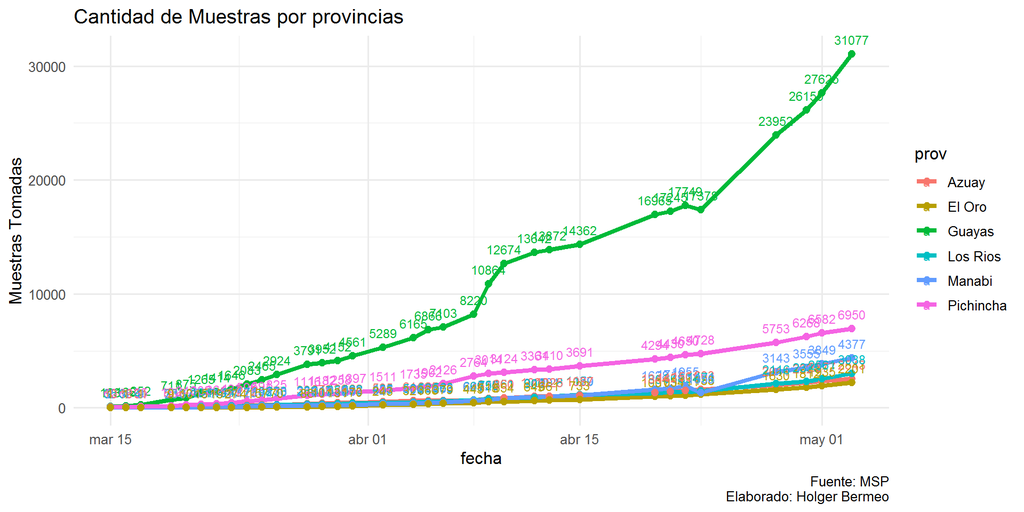

### Muestras diarias en cada provincia

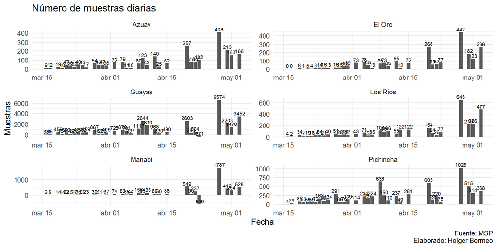

### Condensado muestras diarias en las provincias en análisis

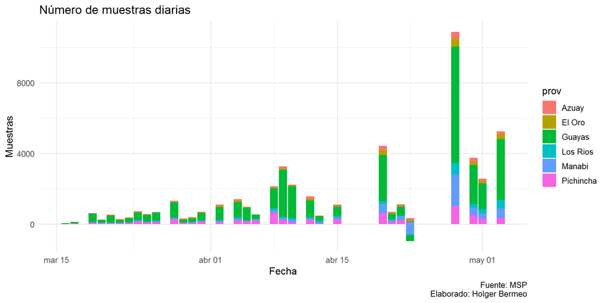

### Tasa de pruebas realizadas por cada 100 mil habitantes

A nivel nacional existe una tasa de 350 pruebas tomadas por cada 100 mil habitantes. Con los datos que se reportan a la fecha esta es la cantidad de pruebas por cada 100mil habitantes que se realiza en las siguientes provincias:

r_pobl= Representatividad poblacional, r_pruebas= representatividad de pruebas

| prov | pobl | r_pobl | tasa | r_pruebas |
| --- | --- | --- | --- | --- |
| Azuay | 881394 | 5 % | 289 | 4.2 % |
| El Oro | 715751 | 4.1 % | 308 | 3.6 % |
| Guayas | 4387434 | 25.1 % | 708 | 50.7 % |
| Los Rios | 921763 | 5.3 % | 330 | 5 % |
| Manabi | 1588627 | 9.1 % | 276 | 7.1 % |
| Pichincha | 3228233 | 18.4 % | 215 | 11.3 % |
| Nacional | 17510643 | NA | 350 | NA |

Nota: La población corresponde a la proyección del INEC con recpecto al 2020 para las provincias mencionadas.

### Porcentajes de pruebas realizadas

Con los datos que se reportan a la fecha estos son los porcentajes de las pruebas en las siguientes provincias:

#### Nacional

p_c= porcentaje confirmadas, p_d= porcentaje descartadas, p_e= porcentaje espera, p_r_c = porcentaje confirmadas de procesadas, p_r_d= porcentaje descartadas de procesadas

| pruebas | Total Pruebas p_c | Total Pruebas p_d | Total Pruebas p_e | Pruebas procesadas p_r_c | Pruebas procesadas p_r_d |
| --- | --- | --- | --- | --- | --- |
| 61262 | 34.18 | 37.2 | 26.48 | 47.88 | 52.12 |

#### Provincias

p_c= porcentaje confirmadas, p_d= porcentaje descartadas, p_e= porcentaje espera, p_r_c = porcentaje confirmadas de procesadas, p_r_d= porcentaje descartadas de procesadas

| prov | Total Pruebas p_c | Total Pruebas p_d | Total Pruebas p_e | Pruebas procesadas p_r_c | Pruebas procesadas p_r_d |
| --- | --- | --- | --- | --- | --- |
| Azuay | 21.67 | 69.17 | 9.08 | 23.85 | 76.15 |
| El Oro | 28.35 | 52.48 | 18.04 | 35.08 | 64.92 |
| Guayas | 42.00 | 31.29 | 24.16 | 57.31 | 42.69 |
| Los Rios | 30.65 | 31.80 | 35.09 | 49.08 | 50.92 |
| Manabi | 21.34 | 18.05 | 55.79 | 54.18 | 45.82 |
| Pichincha | 24.43 | 52.81 | 22.72 | 31.63 | 68.37 |

### Proyección de casos confirmados de muestras de espera

La siguiente es la proyección de casos adicionales que podría haber si se procesaran las muestras en espera y éstas tuviesen la misma probabilidad de confirmación de las muestras que se procesaron anteriormente.

#### Nacional

proy= proyección de casos de pruebas en espera

| confirmadas | proy |
| --- | --- |
| 20937 | 7768 |

#### Provincias

proy= proyección de casos de pruebas en espera

| prov | confirmados | proy |
| --- | --- | --- |
| Azuay | 551 | 55 |
| El Oro | 624 | 139 |
| Guayas | 13053 | 4303 |
| Los Rios | 931 | 523 |
| Manabi | 934 | 1323 |
| Pichincha | 1698 | 499 |

### Letalidad por muertes incluido casos proyectados de muestras en espera (muertes confirmadas con covid19 y probablemente covid19 )

Tasa de letalidad en cada provincia en relación a la suma de número de muertes confirmadas con covid19 mas número de muertes con causa probable de covid19 y los casos confirmados de personas contagiadas por cada provincia mas la proyección de casos confirmados contagiados y los probables. La tasa se refiere al último dato con fecha de 2020-05-03.

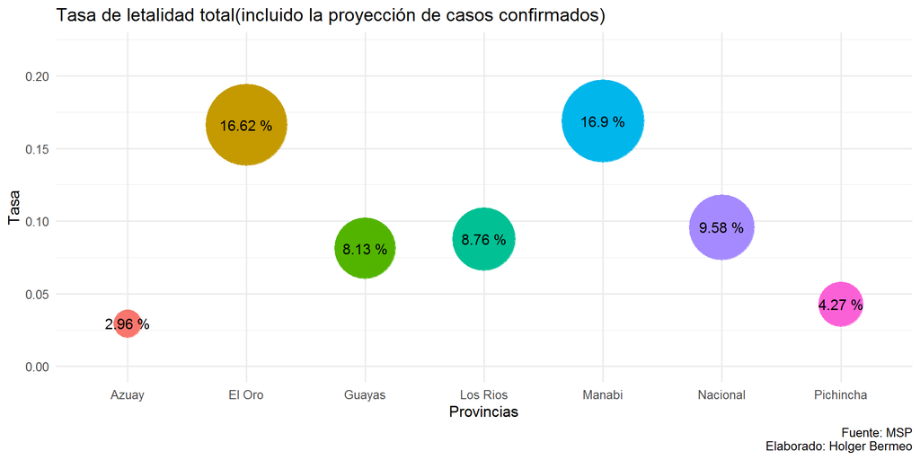

### Letalidad por muertes confirmadas

Tasa de letalidad en cada provincia en relación al número de muertes confirmadas y los casos confirmados de personas contagiadas por cada provincia. La tasa se refiere al último dato con fecha de 2020-05-03.

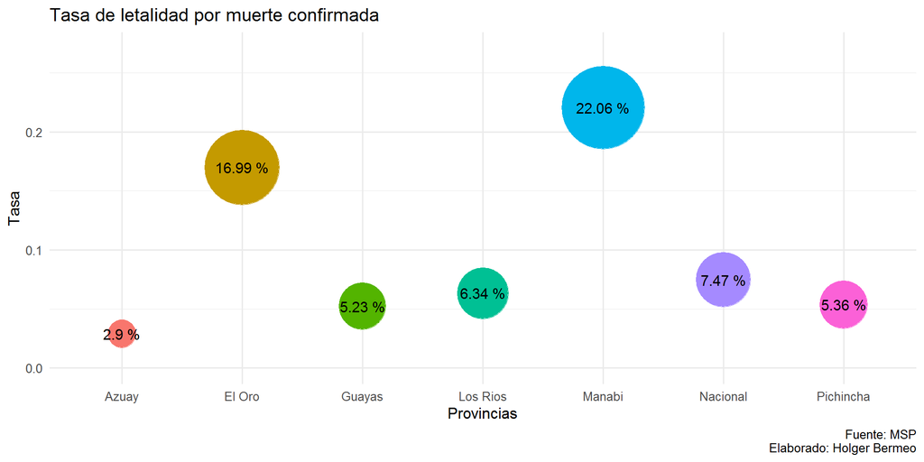

### Letalidad por muertes con causa probable de covid19

Tasa de letalidad en cada provincia en relación al número de muertes con causa probable de covid19 y los casos confirmados de personas contagiadas por cada provincia más la cantidad de personas fallecidas con causa probable de covid19. La tasa se refiere al último dato con fecha de 2020-05-03.

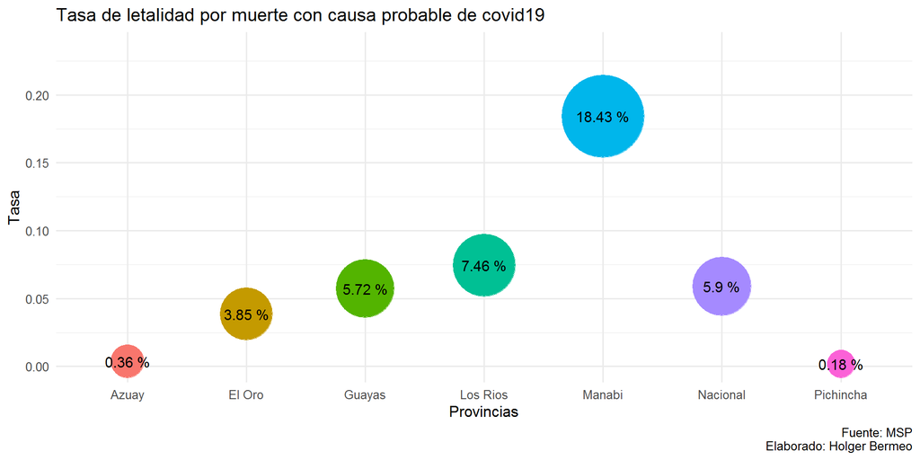

### Letalidad por muertes (muertes confirmadas con covid19 y probablemente covid19 )

Tasa de letalidad en cada provincia en relación a la suma de número de muertes confirmadas con covid19 mas número de muertes con causa probable de covid19 y los casos confirmados de personas contagiadas por cada provincia más los casos de personas fallecidas con causa probable de covid19. La tasa se refiere al último dato con fecha de 2020-05-03.

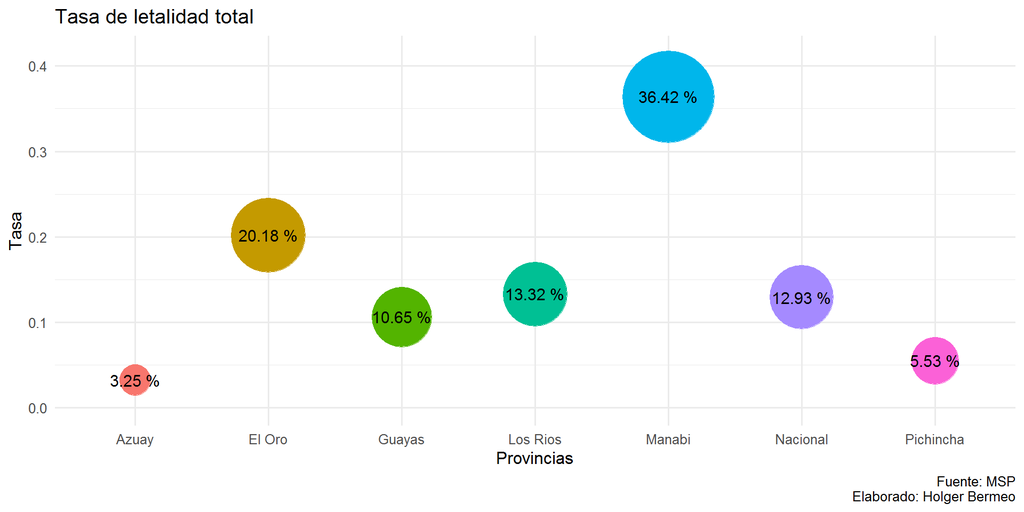

### Evolución de la cantidad de fallecidos total en cada provincia

Evolución de la cantidad total de fallecidos en cada provincia del análisis. Incluye la cantidad de fallecidos confirmados y los probables. Datos hasta la fecha 2020-05-03

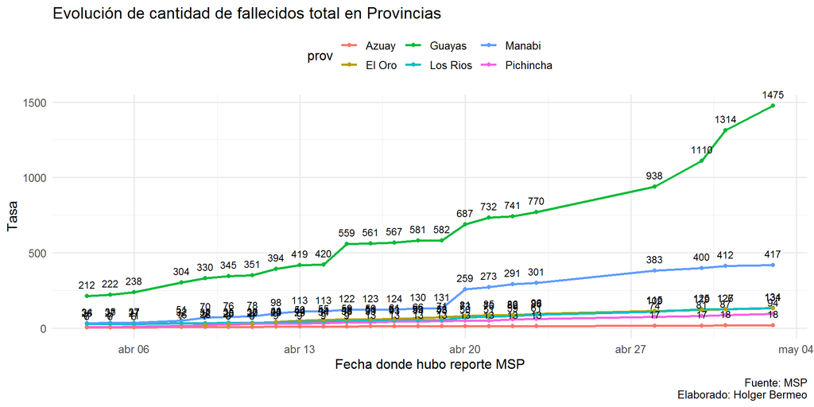

### Evolución de las tasas de letalidad

Evolución de las tasas de letalidad de las provincias con mas fallecidos. La tasa incluye a los fallecidos reportados como confirmados y los que probablemente fallecieron también por covid19. Datos hasta la fecha 2020-05-03

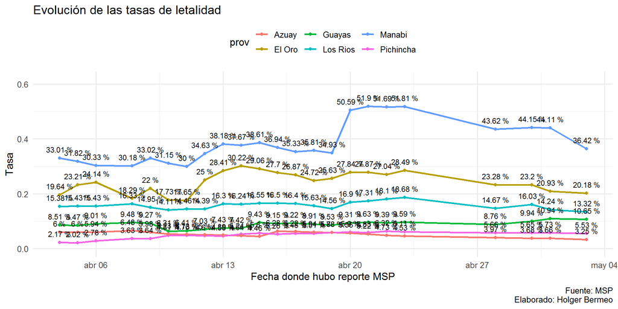

### Análisis de tasas de letalidad y pruebas necesarias en Manabí

El siguiente es una estimación de pruebas necesarias para comprobar tasas de letalidad que existen a nivel mundial. Se realiza a partir de la cantidad de fallecidos total a la fecha. La tasa mínima de letalidad es del 0.0485 y la máxima del 0.0604, se plantean dos escenarios uno estimando que se hacen pruebas y que las confirmaciones son la tasa minima de confirmación de muestras procesadas de las provincias con más fallecidos y otra con las tasas promedio de confirmación de muestras procesadas de las mismas provincias.

tas_prob = Tasa de letalidad probable, prob_contag= Probables contagiados

| Fallecidos | tas_prob | prob_contag | tas_min | prueb_pro |
| --- | --- | --- | --- | --- |
| **Tasa minima** |  |  |  |  |
| 417 | 0.0485 | 8598 | 0.23850 | 36050 |
| 417 | 0.0604 | 6904 | 0.23850 | 28948 |
| **Tasa promedio** |  |  |  |  |
| 417 | 0.0485 | 8598 | 0.41855 | 20542 |
| 417 | 0.0604 | 6904 | 0.41855 | 16495 |

#### Elaborado por:

Arq. Holger Bermeo Cantos